# Scripts to find correlation coefficients

This notebook contains three examples of use of correlation tests on continuous data.

You can copy whichever parts meets your needs, delete the rest and adapt it to your data.

## Example of normally distributed data - no evidence of correlation

**Question**: Is tree height correlated with tree diameter at breast height?

### load packages

```r
library(tidyverse)
library(here)
library(cowplot)
```

### Load data

Here we will choose tree data. Your data file should be a csv file, inside the data subolder of your project

```r
filepath <- here("data","tree_vol.csv")
trees <- read_csv(filepath)
glimpse(trees)
```

```
## Rows: 20
## Columns: 3
## $ diameter <dbl> 0.6917, 0.7167, 0.7333, 0.8750, 0.8917, 0.9000, 0.9167, 0.916…
## $ height   <dbl> 70, 65, 63, 72, 81, 83, 66, 75, 80, 75, 79, 76, 76, 69, 75, 7…
## $ volume   <dbl> 10.3, 10.3, 10.2, 16.4, 18.8, 19.7, 15.6, 18.2, 22.6, 19.9, 2…
```

### Plot the data

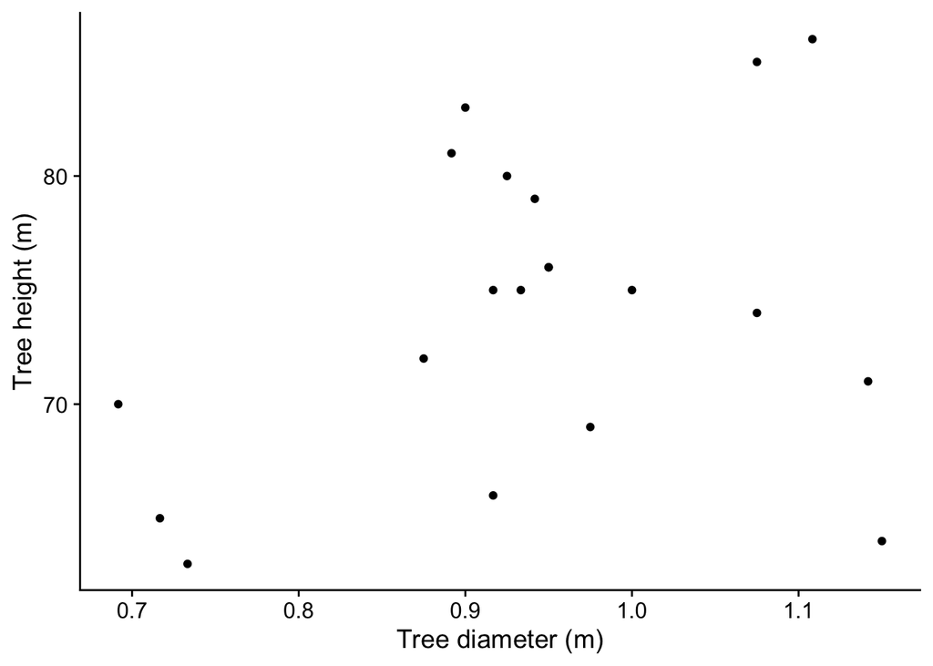

```r
trees %>%
  ggplot(aes(x = diameter, y = height)) + # what we want to plot
  geom_point() + # what kind of plot
  labs(x = "Tree diameter (m)",
       y = "Tree height (m)") + # axis labels
  theme_cowplot() # give the plot a nice 'look'
```

Does it look as though tree diameter and height are linearly correlated?

#### Check for normality

```r
shapiro.test(trees$diameter)
```

```
##
##  Shapiro-Wilk normality test
##
## data:  trees$diameter
## W = 0.93354, p-value = 0.1806
```

```r
shapiro.test(trees$height)
```

```
##
##  Shapiro-Wilk normality test
##
## data:  trees$height
## W = 0.96675, p-value = 0.6854
```

If p > 0.05 in both cases, then we can assume normality

If both are distributed normally, then we check for Pearson’s r, if not we check for Spearman’s Rank r

### Find correlation coefficient

```r
cor.test(trees$diameter,trees$height, method = "pearson")
```

```
##
##  Pearson's product-moment correlation
##
## data:  trees$diameter and trees$height
## t = 1.4687, df = 18, p-value = 0.1592
## alternative hypothesis: true correlation is not equal to 0
## 95 percent confidence interval:
##  -0.134924  0.672323
## sample estimates:
##       cor
## 0.3271285
```

#### Interpret the output

- What is r?
- Is p < 0.05?
- Does the confidence interval encompass zero?
- Is r significantly different from zero?